# Course Project

Xi Fang

6/26/2020

## Background

Using devices such as Jawbone Up, Nike FuelBand, and Fitbit it is now possible to collect a large amount of data about personal activity relatively inexpensively. These type of devices are part of the quantified self movement – a group of enthusiasts who take measurements about themselves regularly to improve their health, to find patterns in their behavior, or because they are tech geeks. One thing that people regularly do is quantify how much of a particular activity they do, but they rarely quantify how well they do it. In this project, your goal will be to use data from accelerometers on the belt, forearm, arm, and dumbell of 6 participants. They were asked to perform barbell lifts correctly and incorrectly in 5 different ways. More information is available from the website here: http://groupware.les.inf.puc-rio.br/har (see the section on the Weight Lifting Exercise Dataset).

## Data

The training data for this project are available here:

https://d396qusza40orc.cloudfront.net/predmachlearn/pml-training.csv

The test data are available here:

https://d396qusza40orc.cloudfront.net/predmachlearn/pml-testing.csv

The data for this project come from this source: http://groupware.les.inf.puc-rio.br/har. If you use the document you create for this class for any purpose please cite them as they have been very generous in allowing their data to be used for this kind of assignment.

## Goals

The goal of your project is to predict the manner in which they did the exercise. This is the “classe” variable in the training set. You may use any of the other variables to predict with. You should create a report describing how you built your model, how you used cross validation, what you think the expected out of sample error is, and why you made the choices you did. You will also use your prediction model to predict 20 different test cases.

## Data processing

```r
tr <- read.csv("pml-training.csv")
valid <- read.csv("pml-testing.csv")

## Remove columns with more than 90% NA
training <- tr[, which(colMeans(!is.na(tr)) > 0.9)]
# validate <- valid[, which(colMeans(!is.na(valid)) > 0.9)]
dim(training)
```

```
## [1] 19622    93
```

```r
## Remoce columns with nearly 0 variance
zero <- nearZeroVar(training)
training <- training[,-zero]
# validate <- validate[,-zero]
dim(training)
```

```
## [1] 19622    59
```

```r
## Remove the first 5 columns that contains only identification information
training <- training[,-c(1:5)]
# validate <- validate[,-c(1:5)]

## prepare data for prediction
set.seed(123)
inTrain <- createDataPartition(training$classe, p=0.7, list = FALSE)
trainingdata <- training[inTrain,]
testingdata <- training[-inTrain,]
dim(trainingdata)
```

```
## [1] 13737    54
```

```r
dim(testingdata)
```

```
## [1] 5885   54
```

## Correlation analysis for potential predictors

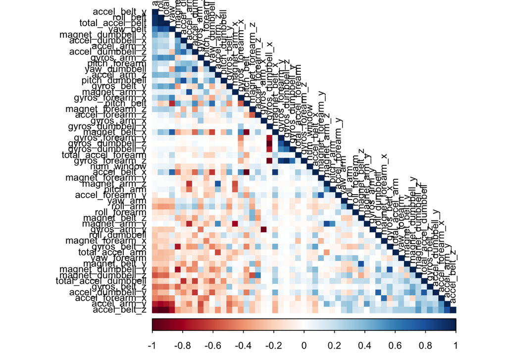

```r
matrix <- cor(trainingdata[,-54])
library(corrplot)
corrplot(matrix, order = "FPC", method = "color", type = "lower", tl.cex = 0.8, tl.col = rgb(0,0,0))
```

Dark color in the heatmap indicates variabls highly correlated to each other. We will select the highly-correlated variables out (r=0.75)

```r
highcorr <- findCorrelation(matrix, cutoff = 0.75)
names(trainingdata)[highcorr]
```

```
##  [1] "accel_belt_z"      "roll_belt"         "accel_belt_y"
##  [4] "accel_arm_y"       "total_accel_belt"  "accel_dumbbell_z"
##  [7] "accel_belt_x"      "pitch_belt"        "magnet_dumbbell_x"
## [10] "accel_dumbbell_y"  "magnet_dumbbell_y" "accel_arm_x"
## [13] "accel_dumbbell_x"  "accel_arm_z"       "magnet_arm_y"
## [16] "magnet_belt_z"     "accel_forearm_y"   "gyros_forearm_y"
## [19] "gyros_dumbbell_x"  "gyros_dumbbell_z"  "gyros_arm_x"
```

## Model buiding

For this project, we will build three prediction models using classification tree, random forests, and gradient boosting machine.

### Classification trees (decision tree)

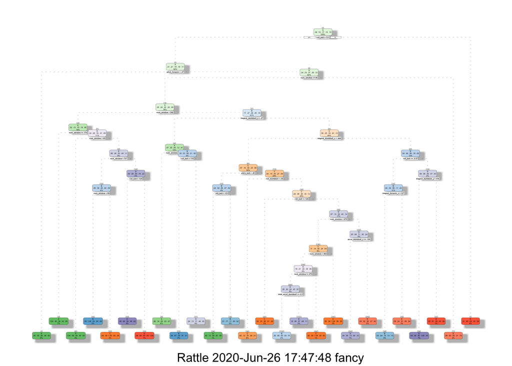

```r
set.seed(12345)
library(rpart)
treemodel <- rpart(classe ~., data=trainingdata, method="class")
fancyRpartPlot(treemodel)
```

```r
## Validate "decision tree" on the testing data
predict_tree <- predict(treemodel, newdata= testingdata, type = "class")
f <- as.factor(testingdata$classe)
conMatrixtree <- confusionMatrix(f,predict_tree)
conMatrixtree
```

```
## Confusion Matrix and Statistics
##
##           Reference
## Prediction    A    B    C    D    E
##          A 1459  104    0   92   19
##          B   86  855   57   81   60
##          C    0   61  856   99   10
##          D   13   75   37  759   80
##          E    2   51    3   86  940
##
## Overall Statistics
##
##                Accuracy : 0.8274
##                  95% CI : (0.8175, 0.8369)
##     No Information Rate : 0.2651
##     P-Value [Acc > NIR] : < 2.2e-16
##
##                   Kappa : 0.7823
##
##  Mcnemar's Test P-Value : NA
##
## Statistics by Class:
##
##                      Class: A Class: B Class: C Class: D Class: E
## Sensitivity            0.9353   0.7461   0.8982   0.6795   0.8476
## Specificity            0.9503   0.9401   0.9655   0.9570   0.9703
## Pos Pred Value         0.8716   0.7507   0.8343   0.7873   0.8688
## Neg Pred Value         0.9760   0.9387   0.9800   0.9273   0.9648
## Prevalence             0.2651   0.1947   0.1619   0.1898   0.1884
## Detection Rate         0.2479   0.1453   0.1455   0.1290   0.1597
## Detection Prevalence   0.2845   0.1935   0.1743   0.1638   0.1839
## Balanced Accuracy      0.9428   0.8431   0.9319   0.8183   0.9089
```

```r
conMatrixtree$overall[1]
```

```
##  Accuracy
## 0.8273577
```

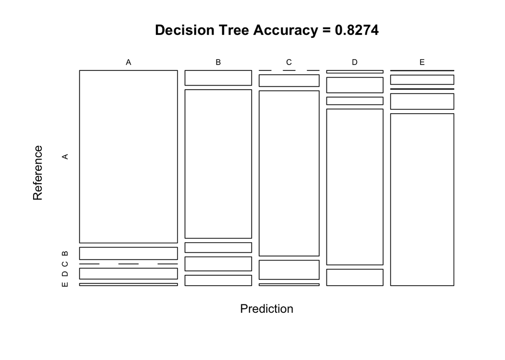

```r
## plot the matrix
plot(conMatrixtree$table, col=conMatrixtree$byClass,
     main=paste("Decision Tree Accuracy =",
                round(conMatrixtree$overall['Accuracy'],4)))
```

### Random Forest

```r
set.seed(12345)
controlRF <- trainControl(method="cv", number=3, verboseIter=FALSE)
rfmodel <- train(classe ~., data=trainingdata, method="rf", trControl=controlRF)

## Validate "rfmodel" on the testing data
predictrf <- predict(rfmodel, newdata = testingdata)
f <- as.factor(testingdata$classe)
conMatrixrf <- confusionMatrix(predictrf, f)
conMatrixrf
```

```
## Confusion Matrix and Statistics
##
##           Reference
## Prediction    A    B    C    D    E
##          A 1674    1    0    0    0
##          B    0 1135    1    0    0
##          C    0    3 1025    1    0
##          D    0    0    0  963    4
##          E    0    0    0    0 1078
##
## Overall Statistics
##
##                Accuracy : 0.9983
##                  95% CI : (0.9969, 0.9992)
##     No Information Rate : 0.2845
##     P-Value [Acc > NIR] : < 2.2e-16
##
##                   Kappa : 0.9979
##
##  Mcnemar's Test P-Value : NA
##
## Statistics by Class:
##
##                      Class: A Class: B Class: C Class: D Class: E
## Sensitivity            1.0000   0.9965   0.9990   0.9990   0.9963
## Specificity            0.9998   0.9998   0.9992   0.9992   1.0000
## Pos Pred Value         0.9994   0.9991   0.9961   0.9959   1.0000
## Neg Pred Value         1.0000   0.9992   0.9998   0.9998   0.9992
## Prevalence             0.2845   0.1935   0.1743   0.1638   0.1839
## Detection Rate         0.2845   0.1929   0.1742   0.1636   0.1832
## Detection Prevalence   0.2846   0.1930   0.1749   0.1643   0.1832
## Balanced Accuracy      0.9999   0.9981   0.9991   0.9991   0.9982
```

```r
conMatrixrf$overall[1]
```

```
##  Accuracy
## 0.9983008
```

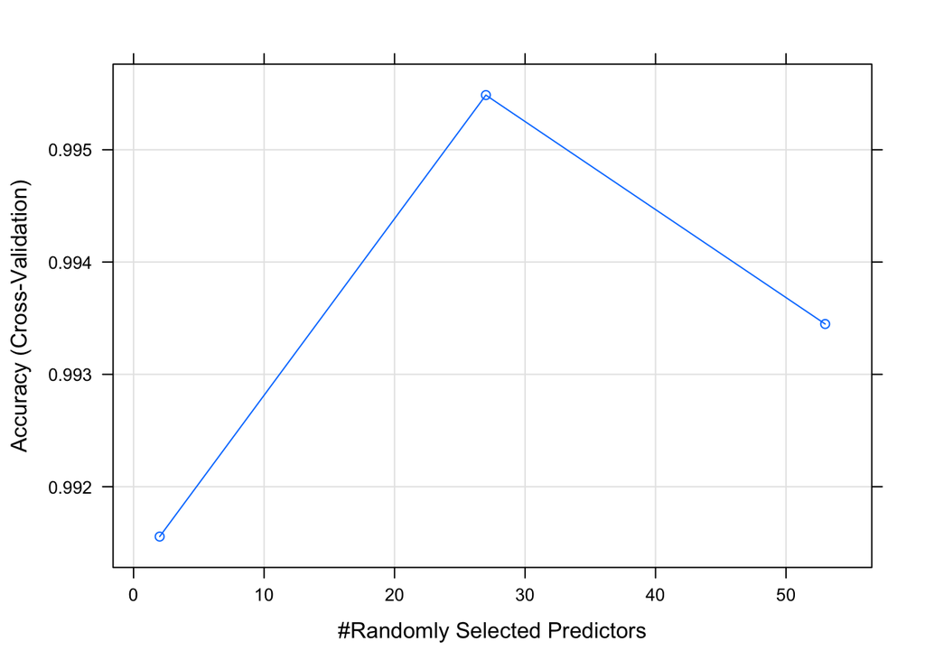

```r
## the accuracy is very high = 0.9983, so the out-of-sample-error is almost 0.
plot(rfmodel)
```

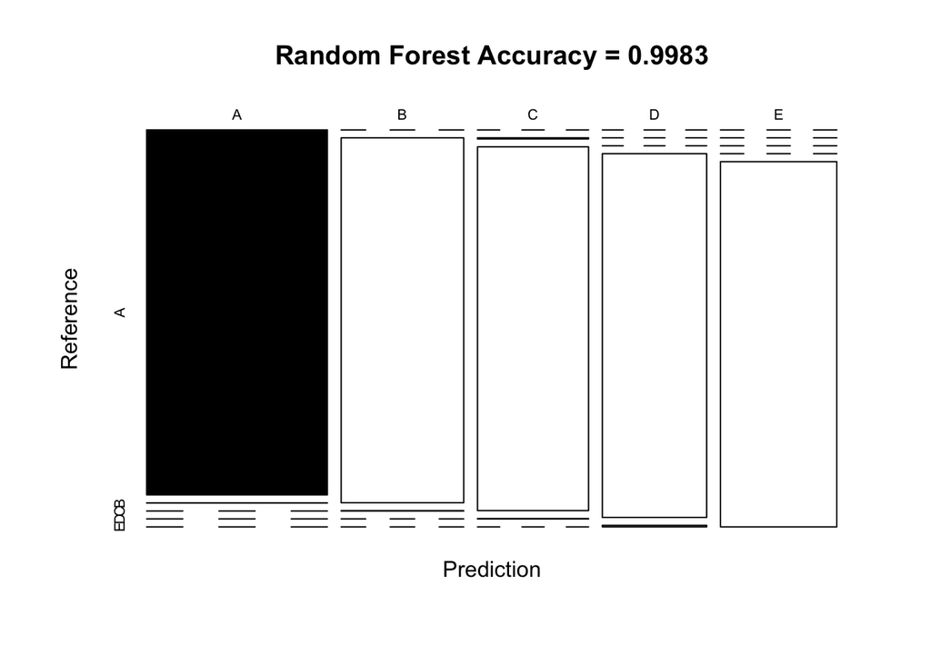

```r
## plot the matrix
plot(conMatrixrf$table, col=conMatrixrf$byClass,
     main=paste("Random Forest Accuracy =",
                round(conMatrixrf$overall['Accuracy'],4)))
```

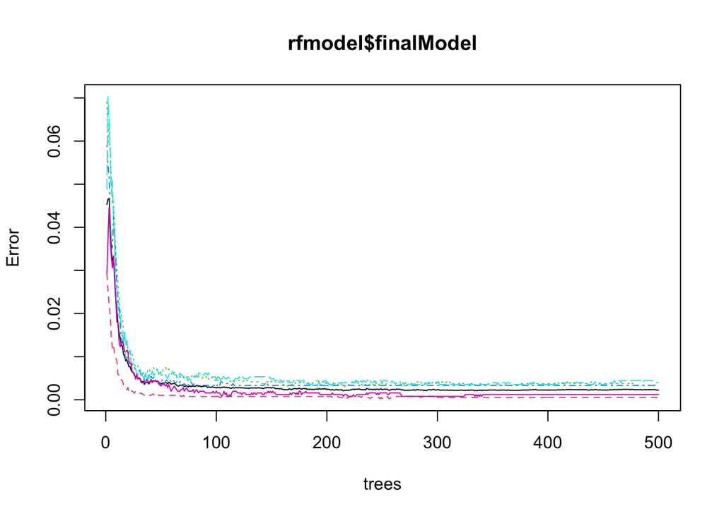

```r
plot(rfmodel$finalModel)
```

### Gradient Boosting Machines

```r
set.seed(12345)
controlRF <- trainControl(method="cv", number=3, verboseIter=FALSE)
gbmmodel <- train(classe ~., data=trainingdata, method="gbm", trControl=controlRF, verbose=FALSE)

## Validate "gbmmodel" on the testing data
predictgbm <- predict(gbmmodel, newdata = testingdata)
f <- as.factor(testingdata$classe)
conMatrixgbm <- confusionMatrix(predictgbm, f)
conMatrixgbm
```

```
## Confusion Matrix and Statistics
##
##           Reference
## Prediction    A    B    C    D    E
##          A 1669    6    0    0    2
##          B    3 1114    9    6    0
##          C    0   18 1016   11    6
##          D    0    1    1  946   13
##          E    2    0    0    1 1061
##
## Overall Statistics
##
##                Accuracy : 0.9866
##                  95% CI : (0.9833, 0.9894)
##     No Information Rate : 0.2845
##     P-Value [Acc > NIR] : < 2.2e-16
##
##                   Kappa : 0.983
##
##  Mcnemar's Test P-Value : NA
##
## Statistics by Class:
##
##                      Class: A Class: B Class: C Class: D Class: E
## Sensitivity            0.9970   0.9781   0.9903   0.9813   0.9806
## Specificity            0.9981   0.9962   0.9928   0.9970   0.9994
## Pos Pred Value         0.9952   0.9841   0.9667   0.9844   0.9972
## Neg Pred Value         0.9988   0.9947   0.9979   0.9963   0.9956
## Prevalence             0.2845   0.1935   0.1743   0.1638   0.1839
## Detection Rate         0.2836   0.1893   0.1726   0.1607   0.1803
## Detection Prevalence   0.2850   0.1924   0.1786   0.1633   0.1808
## Balanced Accuracy      0.9976   0.9871   0.9915   0.9891   0.9900
```